# AFM 346 Final Project - Baseline Model

Derek Shat

12/15/2021

```r
library(tidyverse)
library(readxl)
library(tidymodels)
library(GGally)
library(knitr)
library(doParallel)
library(tictoc)
library(janitor)
```

```r
credit_raw <- read_xls("default of credit card clients.xls", skip = 1)

credit_dt <- credit_raw %>%
  clean_names() %>%
        select(default = default_payment_next_month,
               everything()) %>%
  mutate(across(.cols = c('default','sex',
                          'education', 'marriage',
                          matches('pay_[0-9]')),
                as_factor))

set.seed(123)
credit_split <- initial_split(credit_dt, prop = 0.7, strata = default)
credit_train <- training(credit_split)
credit_test <- testing(credit_split)
set.seed(456)
credit_folds <- credit_train %>%
  vfold_cv(v = 5, repeats = 5, strata = default)

perf_meas <- metric_set(kap,f_meas,roc_auc,mn_log_loss)
```

# Baseline Model

As a baseline model to compare the recommendations to, I decided to use a decision tree model. This is a simple model that tries to classify the information by recursively subsetting the data to purify it as much as possible and reach a classification.

The hyperparameters used in this model are tree_depth, min_n, and cost_complexity. tree_depth specifies how many times the data is subset. min_n specifies the number of observations must be in a node before subsetting. Cost complexity removes partitions from the subsetted data that does not result in purer data.

Before training the model, the only preprocessing step taken was to turn the categorical variables into dummy variables so that they could be used as predictors for the default.

The best results seem to appear when tree depth is set at 6, min_n is set anywhere between 2 and 10, and cost complexity is extremely low and almost 0, for a kappa of around 0.36.

```r
base_recipe <-
  recipe(default~., data = credit_train) %>%
  update_role(id, new_role = 'ID') %>%
  step_dummy(sex:pay_6,-age)

dt_mod <-
  decision_tree(tree_depth = tune(),
                min_n = tune(),
                cost_complexity = tune()) %>%
  set_mode('classification') %>%
  set_engine('rpart')

base_wf <-
  workflow() %>%
  add_recipe(base_recipe) %>%
  add_model(dt_mod)

dt_grid <- grid_latin_hypercube(tree_depth(range = c(4,7)),
                                min_n(range = c(2,10)),
                                cost_complexity(range = c(-10,-9)),
                                size = 20)

all_cores <- parallel::detectCores(logical = FALSE)
cl <- makePSOCKcluster(all_cores)
registerDoParallel(cl)

tic()
base_tune <- base_wf %>%
  tune_grid(
    credit_folds,
    grid = dt_grid,
    metrics = perf_meas,
    control = control_resamples(save_pred=TRUE)
    )
toc()
```

```
## 409.95 sec elapsed
```

```r
stopCluster(cl)

show_best(base_tune, metric = "kap") %>% kable(digits = 3)
```

| cost_complexity | tree_depth | min_n | .metric | .estimator | mean | n | std_err | .config |
| --- | --- | --- | --- | --- | --- | --- | --- | --- |
| 0 | 6 | 5 | kap | binary | 0.359 | 25 | 0.004 | Preprocessor1_Model07 |
| 0 | 6 | 3 | kap | binary | 0.358 | 25 | 0.004 | Preprocessor1_Model16 |
| 0 | 6 | 3 | kap | binary | 0.358 | 25 | 0.004 | Preprocessor1_Model20 |
| 0 | 6 | 4 | kap | binary | 0.358 | 25 | 0.004 | Preprocessor1_Model13 |
| 0 | 6 | 7 | kap | binary | 0.358 | 25 | 0.004 | Preprocessor1_Model04 |

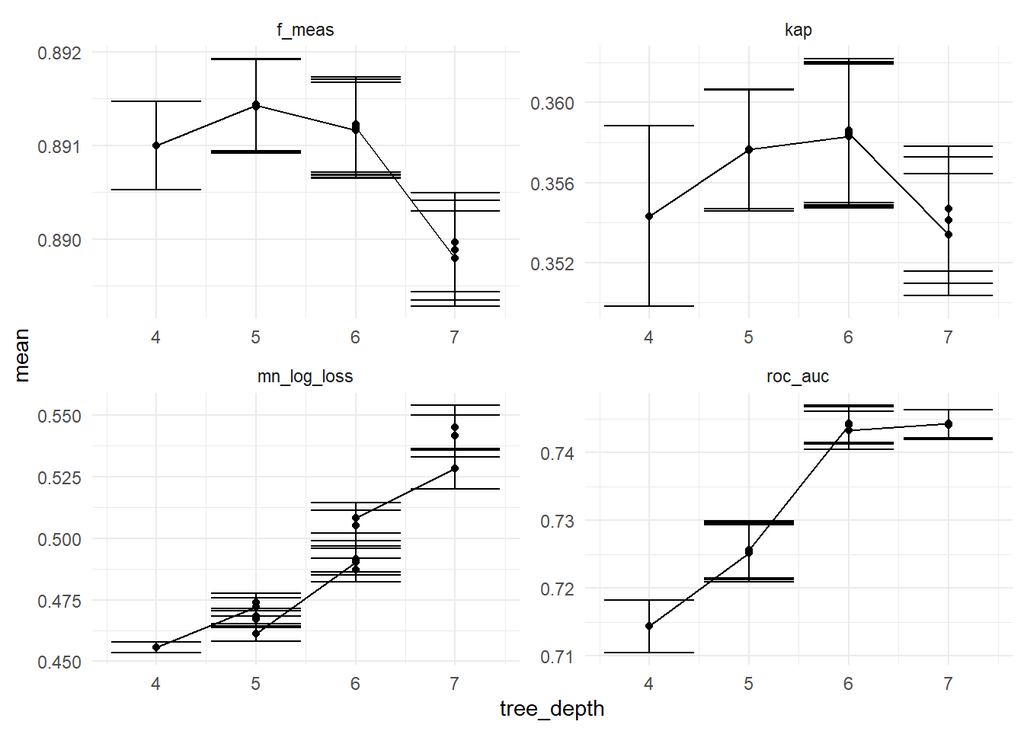

```r
base_tune %>%
  collect_metrics() %>%
  ggplot(aes(x = tree_depth, y = mean)) +
  geom_point() +
  geom_line() +
  geom_errorbar(
    aes(ymin = mean - std_err,
        ymax = mean + std_err)) +
  facet_wrap(~.metric, scales = 'free', ncol = 2) +
  theme_minimal()
```

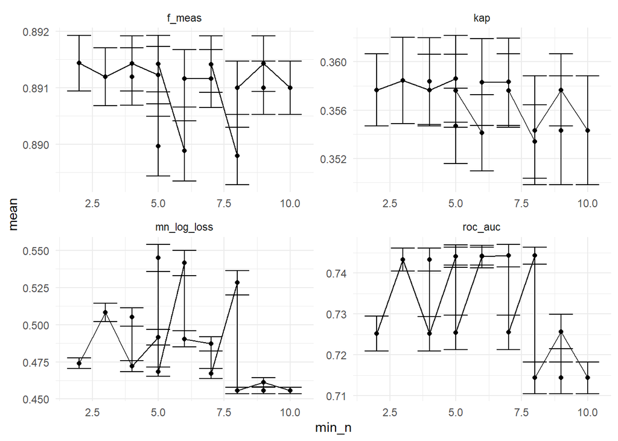

```r
base_tune %>%
  collect_metrics() %>%
  ggplot(aes(x = min_n, y = mean)) +
  geom_point() +
  geom_line() +
  geom_errorbar(
    aes(ymin = mean - std_err,
        ymax = mean + std_err)) +
  facet_wrap(~.metric, scales = 'free', ncol = 2) +
  theme_minimal()
```

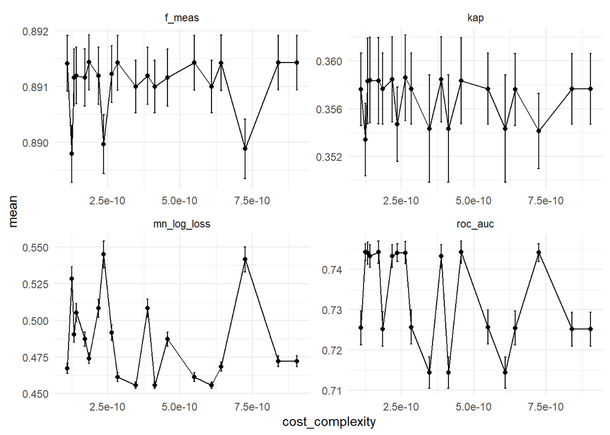

```r
base_tune %>%
  collect_metrics() %>%
  ggplot(aes(x = cost_complexity, y = mean)) +
  geom_point() +
  geom_line() +
  geom_errorbar(
    aes(ymin = mean - std_err,
        ymax = mean + std_err)) +
  facet_wrap(~.metric, scales = 'free', ncol = 2) +
  theme_minimal()
```